# 01 – Explore the CausalCCC authors’ files (case study 1)

CD4⁺ (sender) → CD8⁺ (receiver) T cells, inguinal lymph nodes, NicheNet L-R pairs

Author

Minh Le, Jeanne Leclerc

Published

October 11, 2026

## Goal

Before rebuilding anything ourselves, we look closely at the files the CausalCCC authors used to produce Figure 2 of the paper. They were downloaded by `scripts/case1/download_case1.sh` from the web server job `eaP9Br0llvzxN07zZZEC` (sources in `data/README.md`). We want to understand:

1. what CausalCCC takes as input (the “mosaic” table, the variable list, the L-R pairs) and with which settings it ran;
2. what it produces (the network edge list) and how to read it;
3. whether the published network supports what the paper says about Figure 2.

This notebook only **reads** files: nothing in `data/` is modified and nothing is written.

## Setup

We load the tidyverse, a collection of packages for reading tables (`readr`), transforming them (`dplyr`, `tidyr`), handling text (`stringr`) and plotting (`ggplot2`).

Then we locate the repository folder. When you run chunks one by one in Positron, R usually works from the repository folder; when Quarto renders the whole notebook, R works from `notebooks/`. The small function below walks up the folders until it finds the repository root, so that the same paths work in both cases.

```r
library(tidyverse)

find_repo_root <- function(dir = getwd()) {
  # The repository root is the folder that contains both README.md and notebooks/
  while (!(file.exists(file.path(dir, "README.md")) && dir.exists(file.path(dir, "notebooks")))) {
    parent <- dirname(dir)
    if (parent == dir) stop("Repository root not found. Open the repository folder in Positron.")
    dir <- parent
  }
  dir
}

root    <- find_repo_root()
job_dir <- file.path(root, "data", "case1", "causalccc_server_eaP9Br0llvzxN07zZZEC")

if (!dir.exists(job_dir)) stop("Data not found: run scripts/case1/download_case1.sh first.")
```

## 1. Read the files

Five files matter here:

- `input.tsv`: the expression table uploaded to the server, one row per cell, one column per gene;
- `clean_state_order.tsv`: one row per variable (gene), with its type and its group (ligand, receptor, …);
- `clean_interact_edges.tsv`: the L-R pairs. It has no header line, so we name the two columns ourselves;
- `edgesList.miic.summary.txt`: the network computed by the server;
- `whole_run.log`: the log of the server run, which contains the exact command.

```r
mosaic      <- read_tsv(file.path(job_dir, "input.tsv"), show_col_types = FALSE)
state_order <- read_tsv(file.path(job_dir, "clean_state_order.tsv"), show_col_types = FALSE)
lr_pairs    <- read_tsv(file.path(job_dir, "clean_interact_edges.tsv"),
                        col_names = c("ligand", "receptor"), show_col_types = FALSE)
edges       <- read_tsv(file.path(job_dir, "edgesList.miic.summary.txt"), show_col_types = FALSE)
run_log     <- read_lines(file.path(job_dir, "whole_run.log"))

# Size of each table
tibble(
  table   = c("mosaic", "state_order", "lr_pairs", "edges"),
  rows    = c(nrow(mosaic), nrow(state_order), nrow(lr_pairs), nrow(edges)),
  columns = c(ncol(mosaic), ncol(state_order), ncol(lr_pairs), ncol(edges))
)
```

```
# A tibble: 4 × 3
  table        rows columns
  <chr>       <int>   <int>
1 mosaic       4207     144
2 state_order   144       6
3 lr_pairs       18       2
4 edges        3798      17
```

## 2. How the server ran

The log records the R command the server executed. We extract that line and print one option per line to make it readable.

```r
run_log |>
  str_subset("^Rscript") |>                   # keep the line that starts with "Rscript"
  str_replace_all(" (--?[a-z])", "\n  \\1") |> # put each option (-x or --xxx) on a new line
  cat()
```

```
Rscript /home/miic/miic_webserver/causalCCC_run_analysis.R
  -i /home/miic/server/server_outputs/eaP9Br0llvzxN07zZZEC/input.tsv
  -o /home/miic/server/server_outputs/eaP9Br0llvzxN07zZZEC
  -l orientation
  -e -1
  --complexity nml
  --conf_shuffle 100
  --conf_ratio 0.01
  --consistency no
  --orient_probab_ratio 0.01
  --n_threads 2
  --plots
  --orientation
  --test_MAR
  -s /home/miic/server/server_outputs/eaP9Br0llvzxN07zZZEC/clean_state_order.tsv
  --interact-edges /home/miic/server/server_outputs/eaP9Br0llvzxN07zZZEC/clean_interact_edges.tsv
  --miic_mode S
  --max_nodes 200
```

Our current understanding of the main options (to be checked against the `miic` documentation, `?miic`, in notebook 02):

| Option | Meaning |
| --- | --- |
| `-i`, `-s`, `--interact-edges` | the three input files: mosaic table, state order, L-R pairs |
| `--complexity nml` | how MIIC corrects mutual information for the limited number of cells before deciding whether two genes are linked |
| `--orientation`, `-l orientation` | orient edges when the data allow it, considering that unobserved (latent) variables may exist |
| `--orient_probab_ratio 0.01` | how strong the evidence must be to accept an orientation |
| `--conf_shuffle 100 --conf_ratio 0.01` | confidence filter: compare each link with 100 shuffled versions of the data, remove links that are not clearly better |
| `--consistency no` | an optional extra consistency check, not used |
| `--test_MAR` | a test for missing values, relevant because the mosaic table contains many `NA` (see section 3) |
| `--miic_mode S` | CausalCCC-specific mode of the `causalccc` branch of `miic` |

## 3. The mosaic table

The sender cells (CD4⁺) and the receiver cells (CD8⁺) are **different cells**: there is no cell where we measure both the ligand of a CD4⁺ cell and the receptor of a CD8⁺ cell. CausalCCC therefore stacks them in one table:

- sender cells have values only in the sender genes, whose names end with `_senders`;
- receiver cells have values only in the receiver genes;
- everything else is `NA` (missing).

Seen from afar, the table looks like a mosaic of two filled blocks. MIIC learns links between sender genes from sender cells only, and between receiver genes from receiver cells only; the L-R pairs provide the bridges between the two blocks.

We first sort the columns by side, then find which rows are sender cells: a row is a sender cell if it has at least one value in the sender columns.

```r
sender_cols   <- str_subset(names(mosaic), "_senders$")
receiver_cols <- setdiff(names(mosaic), sender_cols)

# TRUE for a sender cell, FALSE for a receiver cell
is_sender_row <- rowSums(!is.na(mosaic[, sender_cols])) > 0

tibble(
  what   = c("sender genes (columns)", "receiver genes (columns)", "sender cells (rows)", "receiver cells (rows)"),
  number = c(length(sender_cols), length(receiver_cols), sum(is_sender_row), sum(!is_sender_row))
)
```

```
# A tibble: 4 × 2
  what                     number
  <chr>                     <int>
1 sender genes (columns)       55
2 receiver genes (columns)     89
3 sender cells (rows)        2562
4 receiver cells (rows)      1645
```

Now we check that the mosaic is exactly as described: each block completely filled, everything else completely empty.

```r
tibble(
  check = c("sender cells: receiver genes are all NA",
            "receiver cells: sender genes are all NA",
            "sender cells: sender genes have no NA",
            "receiver cells: receiver genes have no NA"),
  ok = c(all(is.na(mosaic[is_sender_row, receiver_cols])),
         all(is.na(mosaic[!is_sender_row, sender_cols])),
         !anyNA(mosaic[is_sender_row, sender_cols]),
         !anyNA(mosaic[!is_sender_row, receiver_cols]))
)
```

```
# A tibble: 4 × 2
  check                                     ok
  <chr>                                     <lgl>
1 sender cells: receiver genes are all NA   TRUE
2 receiver cells: sender genes are all NA   TRUE
3 sender cells: sender genes have no NA     TRUE
4 receiver cells: receiver genes have no NA TRUE
```

Are sender and receiver cells mixed, or grouped? `rle()` (“run length encoding”) counts how many identical values follow each other: one run per block of consecutive rows of the same kind.

```r
rle(is_sender_row)
```

```
Run Length Encoding
  lengths: int [1:2] 1645 2562
  values : logi [1:2] FALSE TRUE
```

A picture of the table makes the structure obvious. We reshape it into a long format (one line per cell × gene), which is what `ggplot2` needs, and colour each position by whether it holds a value.

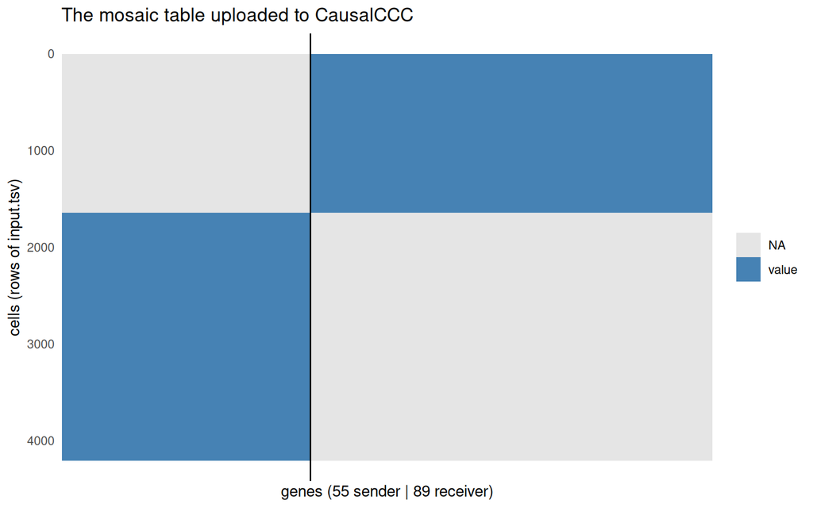

```r
na_pattern <- mosaic |>
  mutate(cell = row_number()) |>
  pivot_longer(-cell, names_to = "gene", values_to = "count") |>
  mutate(has_value = !is.na(count),
         gene      = factor(gene, levels = c(sender_cols, receiver_cols)))

ggplot(na_pattern, aes(x = gene, y = cell, fill = has_value)) +
  geom_raster() +
  geom_vline(xintercept = length(sender_cols) + 0.5) +
  scale_y_reverse() +
  scale_fill_manual(values = c(`TRUE` = "steelblue", `FALSE` = "grey90"),
                    labels = c(`TRUE` = "value", `FALSE` = "NA")) +
  labs(x = paste0("genes (", length(sender_cols), " sender | ", length(receiver_cols), " receiver)"),
       y = "cells (rows of input.tsv)", fill = NULL,
       title = "The mosaic table uploaded to CausalCCC") +
  theme_minimal() +
  theme(axis.text.x = element_blank(), panel.grid = element_blank())
```

## 4. The variables (state order)

The state order describes every variable. `var_type` is 1 for a continuous variable and 0 for a discrete one; `group` is the role of the gene in the network.

```r
count(state_order, group)
```

```
# A tibble: 4 × 2
  group               n
  <chr>           <int>
1 ligands            10
2 receivers genes    81
3 receptors           8
4 senders genes      45
```

```r
# Does the state order describe exactly the columns of the mosaic?
setequal(names(mosaic), state_order$var_names)
```

```
[1] TRUE
```

```r
# Variables declared discrete
state_order |> filter(var_type == 0)
```

```
# A tibble: 1 × 6
  var_names     var_type levels_increasing_order is_contextual group group_color
  <chr>            <dbl> <lgl>                           <dbl> <chr> <chr>
1 Tgfb1_senders        0 NA                                  0 liga… 28827A
```

One ligand is declared discrete while all other variables are continuous. A possible reason is that it takes few different values; we count the number of distinct values of each variable and show the smallest ones.

```r
map_int(mosaic, \(column) n_distinct(column, na.rm = TRUE)) |>
  sort() |>
  head(5)
```

```
  Tgfb1_senders Tgfb1_receivers H2-M3_receivers   H2-M3_senders           Cxcr3
              4               5               6               6               7
```

Gene names: only some names carry a `_senders` or `_receivers` suffix. We split each column name into a gene name and a side, then check two things: how many names have a suffix, and whether the sender genes also appear on the receiver side.

```r
genes <- tibble(variable = names(mosaic)) |>
  mutate(side     = if_else(variable %in% sender_cols, "sender", "receiver"),
         gene     = str_remove(variable, "_(senders|receivers)$"),
         suffixed = str_detect(variable, "_(senders|receivers)$"))

count(genes, side, suffixed)
```

```
# A tibble: 3 × 3
  side     suffixed     n
  <chr>    <lgl>    <int>
1 receiver FALSE       34
2 receiver TRUE        55
3 sender   TRUE        55
```

```r
# Are all sender genes also measured on the receiver side?
all(genes$gene[genes$side == "sender"] %in% genes$gene[genes$side == "receiver"])
```

```
[1] TRUE
```

The suffix is only added when a gene is present on both sides, to tell the two copies apart.

Many selected genes have names like `Gm12345`, `Mir703` or `AL663027.1`: these are predicted genes, microRNA host genes or unnamed loci rather than well-characterised protein-coding genes. We count them, because whether they should be in the network is a question for our assessment of the preprocessing.

```r
genes |>
  mutate(predicted_gene = str_detect(gene, "^(Gm[0-9]|Mir[0-9]|AL[0-9])")) |>
  count(side, predicted_gene)
```

```
# A tibble: 4 × 3
  side     predicted_gene     n
  <chr>    <lgl>          <int>
1 receiver FALSE             65
2 receiver TRUE              24
3 sender   FALSE             45
4 sender   TRUE              10
```

## 5. The ligand–receptor pairs

```r
lr_pairs
```

```
# A tibble: 18 × 2
   ligand         receptor
   <chr>          <chr>
 1 H2-D1_senders  Cd8a
 2 H2-K1_senders  Cd8a
 3 H2-M3_senders  Cd8a
 4 H2-Q4_senders  Cd8a
 5 H2-Q6_senders  Cd8a
 6 H2-Q7_senders  Cd8a
 7 Tgfb1_senders  Tgfbr2
 8 Sell_senders   Selplg
 9 Cxcl10_senders Cxcr3
10 Cd86_senders   Cd28
11 H2-M3_senders  Klrd1
12 H2-D1_senders  Klrd1
13 H2-K1_senders  Klrd1
14 H2-Q4_senders  Klrd1
15 H2-Q6_senders  Klrd1
16 H2-Q7_senders  Klrd1
17 Tgfb1_senders  Itgb1
18 Cxcl10_senders Dpp4
```

```r
# Is every ligand declared as a ligand, and every receptor as a receptor, in the state order?
lr_pairs |>
  summarise(all_ligands_ok   = all(ligand %in% state_order$var_names[state_order$group == "ligands"]),
            all_receptors_ok = all(receptor %in% state_order$var_names[state_order$group == "receptors"]))
```

```
# A tibble: 1 × 2
  all_ligands_ok all_receptors_ok
  <lgl>          <lgl>
1 TRUE           TRUE
```

How widely are these ligands and receptors expressed? For each one we compute, within its own cell type, the fraction of cells where it is detected (count above 0).

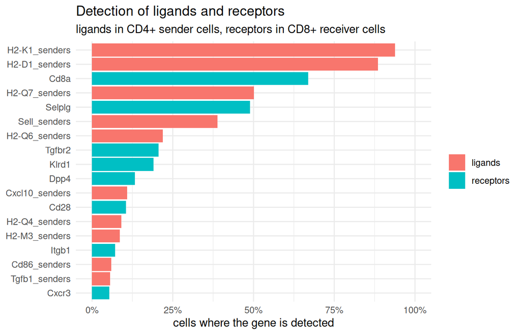

```r
lr_genes <- state_order |>
  filter(group %in% c("ligands", "receptors")) |>
  pull(var_names)

lr_expression <- mosaic |>
  select(all_of(lr_genes)) |>
  pivot_longer(everything(), names_to = "variable", values_to = "count") |>
  filter(!is.na(count)) |>                 # keep only the cells of the gene's own side
  group_by(variable) |>
  summarise(cells = n(), fraction_detected = mean(count > 0), mean_count = mean(count)) |>
  left_join(select(state_order, variable = var_names, group), by = "variable")

ggplot(lr_expression, aes(x = fraction_detected, y = reorder(variable, fraction_detected), fill = group)) +
  geom_col() +
  scale_x_continuous(labels = scales::percent, limits = c(0, 1)) +
  labs(x = "cells where the gene is detected", y = NULL, fill = NULL,
       title    = "Detection of ligands and receptors",
       subtitle = "ligands in CD4+ sender cells, receptors in CD8+ receiver cells") +
  theme_minimal()
```

## 6. The values: raw counts?

The paper asks for raw counts as input. Raw counts are whole numbers of molecules (UMIs), never negative.

```r
values <- unlist(mosaic, use.names = FALSE)
values <- values[!is.na(values)]

tibble(
  minimum       = min(values),
  maximum       = max(values),
  all_integers  = all(values == round(values)),
  fraction_zero = mean(values == 0)
)
```

```
# A tibble: 1 × 4
  minimum maximum all_integers fraction_zero
    <dbl>   <dbl> <lgl>                <dbl>
1       0     415 TRUE                 0.364
```

## 7. The published network

The edge list contains every pair of genes that MIIC examined. The column `type` says whether the link was kept (`P`, present) or rejected (`N`). We keep only the retained links, then sort them into three categories using the side of each gene.

```r
count(edges, type)
```

```
# A tibble: 2 × 2
  type      n
  <chr> <int>
1 N      3434
2 P       364
```

```r
network <- edges |>
  filter(type == "P") |>
  mutate(side_x   = if_else(x %in% sender_cols, "sender", "receiver"),
         side_y   = if_else(y %in% sender_cols, "sender", "receiver"),
         category = case_when(side_x == "sender"   & side_y == "sender"   ~ "within senders (CD4+)",
                              side_x == "receiver" & side_y == "receiver" ~ "within receivers (CD8+)",
                              .default = "ligand-receptor link"))

count(network, category)
```

```
# A tibble: 3 × 2
  category                    n
  <chr>                   <int>
1 ligand-receptor link       18
2 within receivers (CD8+)   218
3 within senders (CD4+)     128
```

The column `Nxy_ai` gives the number of cells used to evaluate each link. It confirms that links between sender genes are learnt from sender cells only, and links between receiver genes from receiver cells only.

```r
count(network, category, cells_used = Nxy_ai)
```

```
# A tibble: 3 × 3
  category                cells_used     n
  <chr>                        <dbl> <int>
1 ligand-receptor link            NA    18
2 within receivers (CD8+)       1645   218
3 within senders (CD4+)         2562   128
```

**Orientation.** The column `infOrt` codes the direction found by MIIC: 1 = not oriented, 2 = x → y, −2 = y → x, 6 = bidirected (a sign of a hidden common cause). The column `is_causal` is `Y` when MIIC considers the edge a genuine causation, which the paper draws with a green arrowhead. The column `proba` holds two probabilities: that of an arrowhead on the x side, then that of an arrowhead on the y side. (The `miic` documentation words it differently; the code that writes the column confirms this reading, see notebook 02, section 6.)

```r
network |>
  mutate(orientation = case_when(infOrt ==  1 ~ "not oriented",
                                 infOrt ==  2 ~ "x -> y",
                                 infOrt == -2 ~ "y -> x",
                                 infOrt ==  6 ~ "bidirected")) |>
  count(category, orientation)
```

```
# A tibble: 9 × 3
  category                orientation      n
  <chr>                   <chr>        <int>
1 ligand-receptor link    x -> y          18
2 within receivers (CD8+) bidirected       1
3 within receivers (CD8+) not oriented   173
4 within receivers (CD8+) x -> y          23
5 within receivers (CD8+) y -> x          21
6 within senders (CD4+)   bidirected       4
7 within senders (CD4+)   not oriented    97
8 within senders (CD4+)   x -> y          15
9 within senders (CD4+)   y -> x          12
```

```r
count(network, is_causal)
```

```
# A tibble: 2 × 2
  is_causal     n
  <chr>     <int>
1 N           351
2 Y            13
```

**Hubs.** The number of links of each gene (its degree) shows which genes organise the network.

```r
bind_rows(select(network, gene = x), select(network, gene = y)) |>
  count(gene, name = "links", sort = TRUE) |>
  head(10)
```

```
# A tibble: 10 × 2
   gene               links
   <chr>              <int>
 1 Ifi27l2b_receivers    28
 2 Ifi27l2b_senders      28
 3 Mir703_receivers      25
 4 B2m_receivers         22
 5 Actb_receivers        17
 6 Gm11942_receivers     17
 7 Irf7_senders          17
 8 B2m_senders           12
 9 Cd8a                  10
10 Irf7_receivers        10
```

## 8. Does the network support the paper’s description of Figure 2?

The paper’s Results section makes four statements about this network. We check each against the edge list. Two small tools first:

- `neighbors_of()` lists the genes directly linked to a given gene;
- `graph_distance()` counts how many links separate a gene from all the others, ignoring directions. It works like ripples in water: step 1 finds the direct neighbours, step 2 their neighbours, and so on until no new gene is reached.

```r
neighbors_of <- function(node, net = network) {
  net |>
    filter(x == node | y == node) |>
    transmute(node, neighbor = if_else(x == node, y, x), infOrt, is_causal)
}

graph_distance <- function(net, from) {
  distance <- setNames(0, from)   # distance 0 for the starting gene
  frontier <- from                # genes reached at the last step
  step     <- 0
  repeat {
    touching  <- net |> filter(x %in% frontier | y %in% frontier)
    new_genes <- setdiff(unique(c(touching$x, touching$y)), names(distance))
    if (length(new_genes) == 0) break
    step     <- step + 1
    distance <- c(distance, setNames(rep(step, length(new_genes)), new_genes))
    frontier <- new_genes
  }
  distance
}

sender_network   <- filter(network, category == "within senders (CD4+)")
receiver_network <- filter(network, category == "within receivers (CD8+)")
```

**Statement 1.** In the CD4⁺ sender network, the MHC class I ligands (H2 genes) have first-degree neighbours including Psmb8, Ifi27l2b, Slfn1, Shisa5, Irf7, Mir703 and B2m.

```r
h2_ligands   <- unique(str_subset(lr_pairs$ligand, "^H2-"))
h2_neighbors <- map(h2_ligands, neighbors_of) |> list_rbind()

claimed <- c("Psmb8", "Ifi27l2b", "Slfn1", "Shisa5", "Irf7", "Mir703", "B2m")

tibble(gene = claimed) |>
  mutate(linked_to = map_chr(gene, \(g) {
    hits <- h2_neighbors |> filter(neighbor == paste0(g, "_senders"))
    if (nrow(hits) == 0) "none" else paste(str_remove(hits$node, "_senders"), collapse = ", ")
  }))
```

```
# A tibble: 7 × 2
  gene     linked_to
  <chr>    <chr>
1 Psmb8    H2-K1
2 Ifi27l2b H2-K1, H2-Q7
3 Slfn1    H2-K1
4 Shisa5   H2-K1
5 Irf7     H2-D1
6 Mir703   H2-D1
7 B2m      H2-D1, H2-K1
```

**Statement 2.** Stat1 is a genuine cause of B2m.

```r
network |>
  filter(x %in% c("Stat1_senders", "B2m_senders"), y %in% c("Stat1_senders", "B2m_senders")) |>
  select(x, y, infOrt, is_causal, proba)
```

```
# A tibble: 1 × 5
  x           y             infOrt is_causal proba
  <chr>       <chr>          <dbl> <chr>     <chr>
1 B2m_senders Stat1_senders     -2 Y         0.999999995470155;0.00015363728681…
```

Here x is B2m and y is Stat1, so `infOrt = -2` means y → x, that is Stat1 → B2m, and `is_causal = Y` marks it as a genuine causation.

**Statement 3.** Stat1 shares direct or indirect associations with IFN-inducible genes (Ifi27l2b, Ifi27l2a, Ifi47) and IFN-stimulated genes (Isg15, Isg20). Distance 1 means a direct link.

```r
distance_from_stat1 <- graph_distance(sender_network, "Stat1_senders")

tibble(gene = c("Ifi27l2b", "Ifi27l2a", "Ifi47", "Isg15", "Isg20")) |>
  mutate(distance_from_Stat1 = distance_from_stat1[paste0(gene, "_senders")])
```

```
# A tibble: 5 × 2
  gene     distance_from_Stat1
  <chr>                  <dbl>
1 Ifi27l2b                   1
2 Ifi27l2a                   2
3 Ifi47                      2
4 Isg15                      2
5 Isg20                      1
```

**Statement 4.** In the CD8⁺ receiver network, downstream interactions of the receptors Cd8a and Klrd1 include Cd8b1 and Ly6c2, Ly6c1 and “Ly6ca”. There is no gene called Ly6ca in the input; we assume a typo for Ly6a, which is present.

```r
neighbors_of("Cd8a")  |> filter(!str_detect(neighbor, "_senders$"))
```

```
# A tibble: 4 × 4
  node  neighbor          infOrt is_causal
  <chr> <chr>              <dbl> <chr>
1 Cd8a  Gm10076_receivers      1 N
2 Cd8a  Cd8b1                  1 N
3 Cd8a  Gm15772                1 N
4 Cd8a  B2m_receivers          1 N
```

```r
neighbors_of("Klrd1") |> filter(!str_detect(neighbor, "_senders$"))
```

```
# A tibble: 1 × 4
  node  neighbor          infOrt is_causal
  <chr> <chr>              <dbl> <chr>
1 Klrd1 Gm10076_receivers      1 N
```

```r
targets <- c("Cd8b1", "Ly6c2_receivers", "Ly6c1_receivers", "Ly6a_receivers")
tibble(gene = targets,
       distance_from_Cd8a  = graph_distance(receiver_network, "Cd8a")[targets],
       distance_from_Klrd1 = graph_distance(receiver_network, "Klrd1")[targets])
```

```
# A tibble: 4 × 3
  gene            distance_from_Cd8a distance_from_Klrd1
  <chr>                        <dbl>               <dbl>
1 Cd8b1                            1                   3
2 Ly6c2_receivers                  2                   2
3 Ly6c1_receivers                  3                   3
4 Ly6a_receivers                   2                   4
```

## What we learned

**Inputs.** The mosaic has 2,562 CD4⁺ sender cells and 1,645 CD8⁺ receiver cells (receivers first, then senders, not shuffled), and 144 genes: 10 ligands and 45 other genes on the sender side, 8 receptors and 81 other genes on the receiver side. All sender genes are also measured on the receiver side. Values are raw integer counts, as the paper requires. There is no column for the condition (steady state or LCMV infection), so both conditions are pooled.

**Network.** 364 links were kept out of 3,798 examined: 128 within senders, 218 within receivers and the 18 L-R links, which were provided rather than learnt. Most links are not oriented; 13 are flagged as genuine causation.

**Paper’s statements.**

- Statement 1 (neighbours of the H2 ligands): fully supported.
- Statement 2 (Stat1 → B2m genuine causation): supported.
- Statement 3 (Stat1 and IFN genes): supported, with direct and indirect links.
- Statement 4 (downstream of Cd8a and Klrd1): only partly. Cd8b1 is a direct but non-oriented neighbour of Cd8a. The Ly6 genes are two to three links away, mostly through non-oriented links, and “Ly6ca” is probably Ly6a. Klrd1 has a single intracellular neighbour, the predicted gene Gm10076.

**Questions for the next notebooks.**

- Can we reproduce this network by running `miic` ourselves on these exact files (notebook 02)?
- Why is one ligand (Tgfb1 in sender cells) declared discrete? It takes only 4 distinct values, the fewest of all variables (answered in notebook 02, section 6).
- Six of the 18 ligands and receptors are detected in fewer than 10 % of their cells (Cxcr3, Tgfb1, Cd86, Itgb1, H2-M3, H2-Q4), and even Cd8a is detected in only two thirds of CD8+ cells. How reliable are links learnt from such sparse genes?
- About a quarter of the variables are predicted genes or microRNA host genes, and some of them (Mir703) are hubs. Is this expected from the gene selection, or a sign of a preprocessing issue?
- Would the network change if the condition (steady state / LCMV) were included as a variable?